# Tutorial 21 - Animations

```python
#importing the usual libraries and modules
import matplotlib.pyplot as plt
import numpy as np
```

## 2 think+type: make a movie

```python
import matplotlib.animation as ani #importing the animation module for matplotlib
```

```python
writer = ani.ImageMagickWriter(fps=5) # create a movie writer object, and set the frames/s it should record at
```

```python
# create a figure, 5x5 in size
fig = plt.figure(figsize=(5,5))
```

```python
print(fig)
```

```
Figure(500x500)
```

```python
 #set things up to save frames to a movie:

    # fig = the figure the writer will record from
    # 'swarm.mp4' = the name of the movie file to save
    # 100 = dpi (dots per inch)

with writer.saving(fig, 'swarm.mp4', 100):

    # Create an array for centroids
    center_arr = np.linspace(-7, 7, 26)
    # loop 25 times
    for i, center in enumerate(center_arr): #sets i as the index number and center as the element in center_arr

        # clear the previous plot
        plt.cla()

        # create the x array
        x= np.random.normal(center, size=[1,1000])

        # create the y array
        y= -1*np.random.normal(center, size=[1,1000])

        #print(f" at i = {i}, x = {x} and y = {y}")
        #checking the points

        # plot the x and y values
        plt.scatter(x, y, color="black")
        plt.axis('scaled')
        plt.xlim(-7,7)
        plt.ylim(-7,7)
        # Provide an update of how far we've gone
        if i % 5 == 0:
            print(f'writing frame #{i}: centered at {center:.1f},{center:.1f}')
            #getting a progress update when the code is running

        # save the current plot as one frame of the movie
        writer.grab_frame()
```

[output not shown]

[output cut: 71 more lines]

[output not shown]

```python
#trying the ivew thevideo file I just created
from IPython.display import Video
Video("swarm.mp4", embed=True)
```

[video not shown]

### since I am struggling with the first video i'm trying to make the sine video from lecture

```python
!rm -rf flipbook
```

```python
!mkdir flipbook
```

```python
N = 25
t = np.linspace(0, 10, N)
y = np.sin(t)
```

```
Saving a plot to flipbook/image00.jpg
Saving a plot to flipbook/image01.jpg
Saving a plot to flipbook/image02.jpg
Saving a plot to flipbook/image03.jpg
Saving a plot to flipbook/image04.jpg
Saving a plot to flipbook/image05.jpg
Saving a plot to flipbook/image06.jpg
Saving a plot to flipbook/image07.jpg
Saving a plot to flipbook/image08.jpg
Saving a plot to flipbook/image09.jpg
Saving a plot to flipbook/image10.jpg
Saving a plot to flipbook/image11.jpg
Saving a plot to flipbook/image12.jpg
Saving a plot to flipbook/image13.jpg
Saving a plot to flipbook/image14.jpg
Saving a plot to flipbook/image15.jpg
Saving a plot to flipbook/image16.jpg
Saving a plot to flipbook/image17.jpg
Saving a plot to flipbook/image18.jpg
Saving a plot to flipbook/image19.jpg
Saving a plot to flipbook/image20.jpg
Saving a plot to flipbook/image21.jpg
Saving a plot to flipbook/image22.jpg
Saving a plot to flipbook/image23.jpg
Saving a plot to flipbook/image24.jpg
```

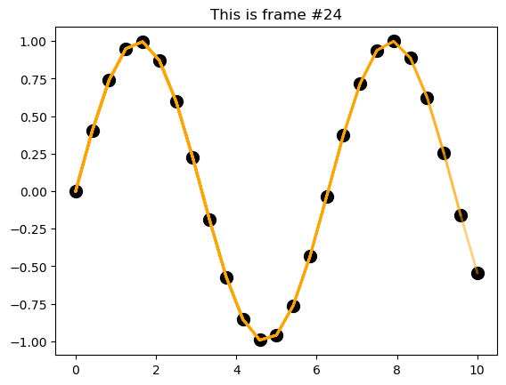

```python
for i in range(N):
    # plot the current point
    plt.scatter(t[i], y[i], color='black', s=100)
    # plot the line up to this point
    plt.plot(t[0:i+1], y[0:i+1], color='orange', linewidth=2, alpha=0.5)

    plt.title(f'This is frame #{i:02}')

    # save to a filename that depends on the frame number
    filename = f'flipbook/image{i:02}.jpg'
    print(f'Saving a plot to {filename}')
    plt.savefig(filename, dpi=200, bbox_inches="tight")
```

```python
!open flipbook/*.jpg
```

```
xdg-open: unexpected argument 'flipbook/image01.jpg'
Try 'xdg-open --help' for more information.
```

```
Saving a plot to flipbook/image00.jpg
Saving a plot to flipbook/image01.jpg
Saving a plot to flipbook/image02.jpg
Saving a plot to flipbook/image03.jpg
Saving a plot to flipbook/image04.jpg
Saving a plot to flipbook/image05.jpg
Saving a plot to flipbook/image06.jpg
Saving a plot to flipbook/image07.jpg
Saving a plot to flipbook/image08.jpg
Saving a plot to flipbook/image09.jpg
Saving a plot to flipbook/image10.jpg
Saving a plot to flipbook/image11.jpg
Saving a plot to flipbook/image12.jpg
Saving a plot to flipbook/image13.jpg
Saving a plot to flipbook/image14.jpg
Saving a plot to flipbook/image15.jpg
Saving a plot to flipbook/image16.jpg
Saving a plot to flipbook/image17.jpg
Saving a plot to flipbook/image18.jpg
Saving a plot to flipbook/image19.jpg
Saving a plot to flipbook/image20.jpg
Saving a plot to flipbook/image21.jpg
Saving a plot to flipbook/image22.jpg
Saving a plot to flipbook/image23.jpg
Saving a plot to flipbook/image24.jpg
```

[figure not shown]

```python
for i in range(N):
    # plot the current point
    plt.scatter(t[i], y[i], color='black', s=100)
    # plot the line up to this point
    plt.plot(t[0:i+1], y[0:i+1], color='orange', linewidth=2, alpha=0.5)
    plt.xlabel("$t$")
    plt.ylabel("$\sin(t)$")
    plt.title(f'This is frame #{i:02}')

    # set the x- & y-limits explicitly, so Python doesn't change them
    plt.ylim(-1.1, 1.1)
    plt.xlim(np.min(t)-1, np.max(t)+1)

    # save to a filename that depends on the frame number
    filename = f'flipbook/image{i:02}.jpg'
    print(f'Saving a plot to {filename}')
    plt.savefig(filename, dpi=200, bbox_inches="tight")
    # clear the axes (= the plot rectangle)
    plt.cla()
```

```python
!open flipbook/*.jpg
```

```
xdg-open: unexpected argument 'flipbook/image01.jpg'
Try 'xdg-open --help' for more information.
```

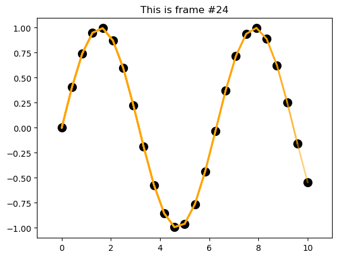

```python
import matplotlib.animation as ani

FFMpegWriter = ani.writers['ffmpeg'] # pull out the definition of a movie-maker CLASS

writer = FFMpegWriter(fps=10) # create a movie write OBJECT, set frames per second

myImage = plt.figure() # create a blank figure object (e.g. blank piece of paper)

myImage.patch.set_alpha(1.0) # this is just a Python bug fix... don't worry about it

with writer.saving(myImage, "sine.mp4", 150):

    for i in range(len(t)):

        # Same plotting code as before
        plt.plot(t[0:i+1], y[0:i+1], color='orange', linewidth=2, alpha=0.5)
        plt.scatter(t[i], y[i], color='black', s=100)
        plt.title(f'This is frame #{i:02}')
        plt.ylim(-1.1,1.1)
        plt.xlim(np.min(t)-1, np.max(t)+1)

        writer.grab_frame() # add the plot to the movie

        #plt.cla() # clear the axes
```

```python
!open sine.mp4
```

```
Error: no "view" rule for type "video/mp4" passed its test case
       (for more information, add "--debug=1" on the command line)
/usr/bin/open: 882: www-browser: not found
/usr/bin/open: 882: links2: not found
/usr/bin/open: 882: elinks: not found
/usr/bin/open: 882: links: not found
/usr/bin/open: 882: lynx: not found
/usr/bin/open: 882: w3m: not found
xdg-open: no method available for opening 'sine.mp4'
```

```python
from IPython.display import Video
Video("sine.mp4", embed=True)
```

[video not shown]

well, that seemed to actually work!!! Now I know how to create a video succsefully I can apply this to the swarm.mp3

## 2 think+type: make a movie (attempt 2)

```
writing frame #0: centered at -7.0,-7.0
writing frame #5: centered at -4.2,-4.2
writing frame #10: centered at -1.4,-1.4
writing frame #15: centered at 1.4,1.4
writing frame #20: centered at 4.2,4.2
writing frame #25: centered at 7.0,7.0
```

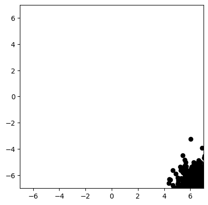

```python
 #set things up to save frames to a movie:

    # fig = the figure the writer will record from
    # 'swarm.mp4' = the name of the movie file to save
    # 100 = dpi (dots per inch)
import matplotlib.animation as ani

FFMpegWriter = ani.writers['ffmpeg'] # pull out the definition of a movie-maker CLASS

writer = FFMpegWriter(fps=10) # create a movie write OBJECT, set frames per second

myImage2 = plt.figure() # create a blank figure object (e.g. blank piece of paper)

myImage2.patch.set_alpha(1.0) # this is just a Python bug fix... don't worry about it

with writer.saving(myImage2, 'swarm.mp4', 100):

    # Create an array for centroids
    center_arr = np.linspace(-7, 7, 26)
    # loop 25 times
    for i, center in enumerate(center_arr): #sets i as the index number and center as the element in center_arr

        # clear the previous plot
        plt.cla()

        # create the x array
        x= np.random.normal(center, size=[1,1000])

        # create the y array
        y= -1*np.random.normal(center, size=[1,1000])

        #print(f" at i = {i}, x = {x} and y = {y}")
        #checking the points

        # plot the x and y values
        plt.scatter(x, y, color="black")
        plt.axis('scaled')
        plt.xlim(-7,7)
        plt.ylim(-7,7)
        # Provide an update of how far we've gone
        if i % 5 == 0:
            print(f'writing frame #{i}: centered at {center:.1f},{center:.1f}')
            #getting a progress update when the code is running

        # save the current plot as one frame of the movie
        writer.grab_frame()
```

```python
!open swarm.mp4
```

```
Error: no "view" rule for type "video/mp4" passed its test case
       (for more information, add "--debug=1" on the command line)
/usr/bin/open: 882: www-browser: not found
/usr/bin/open: 882: links2: not found
/usr/bin/open: 882: elinks: not found
/usr/bin/open: 882: links: not found
/usr/bin/open: 882: lynx: not found
/usr/bin/open: 882: w3m: not found
xdg-open: no method available for opening 'swarm.mp4'
```

well, this already looks to be a lot more successful than my first attempt...

Time to see if the video works and is not just a blank white screen

```python
from IPython.display import Video
Video("swarm.mp4", embed=True)
```

[video not shown]

#### OMG YESSS! The swarm video actually worked that time!!!!

## 3 think+type: make one plot of a light curve

```python
!mkdir lightcurve-plots
```

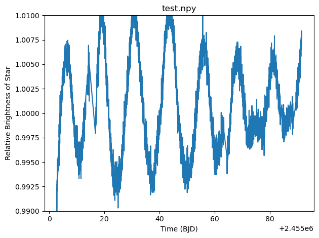

```python
# Set directory to the kepler directory where you unzipped the files
# or leave as is if kepler/ is in the same directory as this tutorial
# (Be sure to use \\ for directories if on Windows.)
directory = 'kepler/'
#this took forever for me to figure out but I finally did it after re reading the pseudo code like 8 times
filename = "test.npy"
# load this file into time and flux arrays
time, flux = np.load(directory + filename)
# clear the existing axes (even if they don't exist yet!)
plt.cla()
# make the plot, add labels, set the limits
plt.plot(time, flux)
plt.title(filename)
plt.xlabel('Time (BJD)')
plt.ylabel('Relative Brightness of Star')
plt.ylim(0.99, 1.01)
# adjust the spacing around the plot, to make it look prettier
plt.tight_layout()
# save the current figure out to a single file
output_filename = 'lightcurve-plots/plot-test.png'
plt.savefig(output_filename)
# in addition to writing the plot to a file, show it in your notebook
plt.show()
```

## 4 think+pair+code: find the exoplanet!

```python
import glob
```

```python
filenames = glob.glob("kepler/KIC*.npy")
#getting all of the files from the kepler folder
```

```python
print(filenames) #making sure that I acutally have a list of all of the files. (You hvae no idea how long this took me to figure out)
```

```
['kepler/KIC6019923.npy', 'kepler/KIC9692092.npy', 'kepler/KIC3641239.npy', 'kepler/KIC4383982.npy', 'kepler/KIC11512270.npy', 'kepler/KIC3660142.npy', 'kepler/KIC7581614.npy', 'kepler/KIC10485913.npy', 'kepler/KIC3424397.npy', 'kepler/KIC7137132.npy', 'kepler/KIC4846450.npy', 'kepler/KIC4048899.npy…
```

```python
print(len(filenames)) #this should be 94 elements long
```

```
94
```

test.npu does not appear in the list because test. npy does not begin with the characters KIC, All the other files begin with the 3 characters KIC

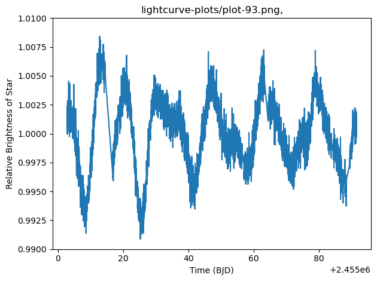

```python
import matplotlib.animation as ani

FFMpegWriter = ani.writers['ffmpeg'] # pull out the definition of a movie-maker CLASS

writer = FFMpegWriter(fps=1) # create a movie write OBJECT, set to 1 frame per second so I can actually analyze the light curves

myImage = plt.figure() # create a blank figure object (e.g. blank piece of paper)

myImage.patch.set_alpha(1.0) # this is just a Python bug fix... don't worry about it

with writer.saving(myImage, "light_curve.mp4", 150):


    for i in range(9):

        directory = 'kepler/'
        #this took forever for me to figure out but I finally did it after re reading the pseudo code like 8 times
        filename = filenames[i]
        # load this file into time and flux arrays
        time, flux = np.load(filename)
        # clear the existing axes (even if they don't exist yet!)
        plt.cla()
        # make the plot, add labels, set the limits
        plt.plot(time, flux)
        plt.title(f"lightcurve-plots/plot-0{i}.png,")
        plt.xlabel('Time (BJD)')
        plt.ylabel('Relative Brightness of Star')
        plt.ylim(0.99, 1.01)
        # adjust the spacing around the plot, to make it look prettier
        plt.tight_layout()
        # save the current figure out to a single file
        output_filename = 'lightcurve-plots/plot-test.png'
        plt.savefig(output_filename)
        # in addition to writing the plot to a file, show it in your notebook
        writer.grab_frame()

    for i in range(10, 94):

        directory = 'kepler/'
        #this took forever for me to figure out but I finally did it after re reading the pseudo code like 8 times
        filename = filenames[i]
        # load this file into time and flux arrays
        time, flux = np.load(filename)
        # clear the existing axes (even if they don't exist yet!)
        plt.cla()
        # make the plot, add labels, set the limits
        plt.plot(time, flux)
        plt.title(f"lightcurve-plots/plot-{i}.png,")
        plt.xlabel('Time (BJD)')
        plt.ylabel('Relative Brightness of Star')
        plt.ylim(0.99, 1.01)
        # adjust the spacing around the plot, to make it look prettier
        plt.tight_layout()
        # save the current figure out to a single file
        output_filename = 'lightcurve-plots/plot-test.png'
        plt.savefig(output_filename)
        # in addition to writing the plot to a file, show it in your notebook
        writer.grab_frame()
```

```python
from IPython.display import Video
Video("light_curve.mp4", embed=True)
```

[video not shown]

Wow you know that feeling when your code actually works the first time?

plot-27 has an unusual solo bump that could be caused by an exoplanet transit

The rest of the plots seem to vary cyclically

## 5 think+write

```python
print(f" the plot-27 is, {filenames[27]} \n the plot-34 is  {filenames[34]}")
```

```
 the plot-27 is, kepler/KIC1295597.npy
 the plot-34 is  kepler/KIC10329669.npy
```

for light curve plot 27, I searched on Google, "does KIC1295597 have exoplanet", and found that the system, KIC1295597, does not have any "confirmed exoplanets". This means I was probably just overanalyzing a systematic abnormality.

For light curve plot 34, I searched on Google, "does KIC10329669 have exoplanet", and found that the system, KIC10329669, also does not currently have any exoplanets.

In both cases, I misunderstood what the light curve was representing with "unusual solo bumps". Sadly, I was not able to find the star system with an exoplanet. Also, please know that I significantly slowed down the video by both lowering the frames per second(fps) and playing the video at 0.25x speed. These were the two star systems I identified as having unusual fluctuations in their relative brightness.